# Exploring HIV Trends and Poverty Dimensions Across WHO Regions

[output not shown]

# 1. Business Understanding

## 1.1 Problem Statement

HIV continues to be a major public health issue in Africa, with a high number of people living with the virus, especially in sub-Saharan regions. While prevention and treatment efforts have improved, HIV is a lifelong condition, making it crucial to track data on this affected. This data helps us identify infection trends, prepare healthcare services to accommodate these patients, and address challenges like stigma and inequality. Beyond health, HIV also impacts jobs, healthcare costs, and poverty levels, making it important to use data to create targeted interventions. By analyzing this information, governments and organizations can better allocate resources and create policies to help reduce transmission and improve the quality of life for those affected.

## 1.2 Objectives

Create a visualization that shows the trend of HIV cases in the countries that contribute to 75% of the global burden  
Generate a visualization that displays the trend of HIV cases in the countries contributing to 75% of the burden within each WHO region (column called ParentLocationCode contains the WHO regions)

# 2. Importing Libraries and Warnings

```python
import warnings
import numpy as np
import pandas as pd
import seaborn as sns
import statsmodels.api as sm
import matplotlib.pyplot as plt
warnings.filterwarnings("ignore")
from statsmodels.regression.mixed_linear_model import MixedLM
```

# 3. Data Understanding

You are provided with a dataset from the World Health Organization (WHO) Global Observatory, containing data on people living with HIV at the country level from 2000 to 2023.

```python
hiv_data = pd.read_csv("data/HIV data 2000-2023.csv", encoding="latin1")
hiv_data
```

```
##        IndicatorCode  ...                        Value
## 0     HIV_0000000001  ...  320 000 [280 000 - 380 000]
## 1     HIV_0000000001  ...  320 000 [280 000 - 380 000]
## 2     HIV_0000000001  ...  320 000 [280 000 - 380 000]
## 3     HIV_0000000001  ...  320 000 [280 000 - 370 000]
## 4     HIV_0000000001  ...  300 000 [260 000 - 350 000]
## ...              ...  ...                          ...
## 1547  HIV_0000000001  ...                      No data
## 1548  HIV_0000000001  ...                      No data
## 1549  HIV_0000000001  ...                      No data
## 1550  HIV_0000000001  ...                      No data
## 1551  HIV_0000000001  ...                      No data
##
## [1552 rows x 11 columns]
```

You have also been provided with World Bank data on the multidimensional poverty headcount ratio, which includes factors such as income, educational attainment, school enrolment, electricity access, sanitation and drinking water.

```python
poverty_data = pd.read_excel("data/multidimensional_poverty.xlsx")
poverty_data
```

```
##     Individuals in households deprived in each indicator, 110 economies, circa year 2021 (2018-2023)\nDate: October 2024  ...                                   Unnamed: 15
## 0                                               Region                                                                    ...  Multidimensional poverty headcount ratio (%)
## 1                                                  NaN                                                                    ...                                           NaN
## 2                                                  SSA                                                                    ...                                     47.203606
## 3                                                  ECA                                                                    ...                                      0.293161
## 4                                                  LAC                                                                    ...                                      0.906573
## ..                                                 ...                                                                    ...                                           ...
## 107                                                ECA                                                                    ...                                      2.253092
## 108                                                EAP                                                                    ...                                      1.266184
## 109                                                EAP                                                                    ...                                     19.892171
## 110                                                SSA                                                                    ...                                     66.506058
## 111                                                SSA                                                                    ...                                     42.397931
##
## [112 rows x 16 columns]
```

We would like you to merge this dataset with the HIV data above and analyze the relationship between people living with HIV and multidimensional poverty, and the individual factors that contribute to the ratio. Remember to account for the random effects (country, year).

```python
hiv_data.columns
```

```
## Index(['IndicatorCode', 'Indicator', 'ValueType', 'ParentLocationCode',
##        'ParentLocation', 'Location type', 'SpatialDimValueCode', 'Location',
##        'Period type', 'Period', 'Value'],
##       dtype='object')
```

```python
poverty_data.columns
```

```
## Index(['Individuals in households deprived in each indicator, 110 economies, circa year 2021 (2018-2023)\nDate: October 2024',
##        'Unnamed: 1', 'Unnamed: 2', 'Unnamed: 3', 'Unnamed: 4', 'Unnamed: 5',
##        'Unnamed: 6', 'Unnamed: 7', 'Unnamed: 8', 'Unnamed: 9', 'Unnamed: 10',
##        'Unnamed: 11', 'Unnamed: 12', 'Unnamed: 13', 'Unnamed: 14',
##        'Unnamed: 15'],
##       dtype='object')
```

```python
hiv_data.info()
```

```
## <class 'pandas.core.frame.DataFrame'>
## RangeIndex: 1552 entries, 0 to 1551
## Data columns (total 11 columns):
##  #   Column               Non-Null Count  Dtype
## ---  ------               --------------  -----
##  0   IndicatorCode        1552 non-null   object
##  1   Indicator            1552 non-null   object
##  2   ValueType            1552 non-null   object
##  3   ParentLocationCode   1552 non-null   object
##  4   ParentLocation       1552 non-null   object
##  5   Location type        1552 non-null   object
##  6   SpatialDimValueCode  1552 non-null   object
##  7   Location             1552 non-null   object
##  8   Period type          1552 non-null   object
##  9   Period               1552 non-null   int64
##  10  Value                1552 non-null   object
## dtypes: int64(1), object(10)
## memory usage: 133.5+ KB
```

```python
poverty_data.info()
```

```
## <class 'pandas.core.frame.DataFrame'>
## RangeIndex: 112 entries, 0 to 111
## Data columns (total 16 columns):
##  #   Column                                                                                                               Non-Null Count  Dtype
## ---  ------                                                                                                               --------------  -----
##  0   Individuals in households deprived in each indicator, 110 economies, circa year 2021 (2018-2023)
## Date: October 2024  111 non-null    object
##  1   Unnamed: 1                                                                                                           111 non-null    object
##  2   Unnamed: 2                                                                                                           111 non-null    object
##  3   Unnamed: 3                                                                                                           111 non-null    object
##  4   Unnamed: 4                                                                                                           111 non-null    object
##  5   Unnamed: 5                                                                                                           111 non-null    object
##  6   Unnamed: 6                                                                                                           111 non-null    object
##  7   Unnamed: 7                                                                                                           111 non-null    object
##  8   Unnamed: 8                                                                                                           111 non-null    object
##  9   Unnamed: 9                                                                                                           112 non-null    object
##  10  Unnamed: 10                                                                                                          111 non-null    object
##  11  Unnamed: 11                                                                                                          111 non-null    object
##  12  Unnamed: 12                                                                                                          111 non-null    object
##  13  Unnamed: 13                                                                                                          111 non-null    object
##  14  Unnamed: 14                                                                                                          111 non-null    object
##  15  Unnamed: 15                                                                                                          111 non-null    object
## dtypes: object(16)
## memory usage: 14.1+ KB
```

```python
hiv_data.describe()
```

```
##             Period
## count  1552.000000
## mean   2014.500000
## std       8.080351
## min    2000.000000
## 25%    2008.750000
## 50%    2017.500000
## 75%    2021.250000
## max    2023.000000
```

```python
poverty_data.describe()
```

```
##        Individuals in households deprived in each indicator, 110 economies, circa year 2021 (2018-2023)\nDate: October 2024  ... Unnamed: 15
## count                                                 111                                                                    ...         111
## unique                                                  8                                                                    ...         109
## top                                                   ECA                                                                    ...           0
## freq                                                   41                                                                    ...           3
##
## [4 rows x 16 columns]
```

```python
hiv_data.shape
```

```
## (1552, 11)
```

```python
poverty_data.shape
```

```
## (112, 16)
```

# 4. Data Cleaning

## Renaming columns

```python
hiv_data.rename(columns={
    'Location': 'Country',
    'Period': 'Year',
    'Value': 'HIV_Population'
}, inplace=True)

hiv_data.columns
```

```
## Index(['IndicatorCode', 'Indicator', 'ValueType', 'ParentLocationCode',
##        'ParentLocation', 'Location type', 'SpatialDimValueCode', 'Country',
##        'Period type', 'Year', 'HIV_Population'],
##       dtype='object')
```

```python
# Rename columns for ease of use
poverty_data.columns = [
    'Region', 'Country_Code', 'Country', 'Year', 'Survey_Name',
    'Survey_Year', 'Survey_Coverage', 'Welfare_Type', 'Survey_Comparability',
    'Monetary', 'Education_Attainment', 'Education_Enrollment',
    'Electricity', 'Sanitation', 'Drinking_Water', 'Multidimensional_Poverty'
]

# Drop the first and second rows
poverty_data = poverty_data.drop(index=[0, 1]).reset_index(drop=True)
poverty_data
```

```
##     Region Country_Code  ... Drinking_Water Multidimensional_Poverty
## 0      SSA          AGO  ...      32.106507                47.203606
## 1      ECA          ALB  ...       9.594966                 0.293161
## 2      LAC          ARG  ...       0.364048                 0.906573
## 3      ECA          ARM  ...       0.660082                 0.523521
## 4      EAP          AUS  ...              -                  2.21577
## ..     ...          ...  ...            ...                      ...
## 105    ECA          UZB  ...      10.693686                 2.253092
## 106    EAP          VNM  ...       1.968127                 1.266184
## 107    EAP          VUT  ...      11.813611                19.892171
## 108    SSA          ZMB  ...      26.849246                66.506058
## 109    SSA          ZWE  ...      19.260145                42.397931
##
## [110 rows x 16 columns]
```

## Keeping only the relevant columns

```python
hiv_data = hiv_data[['Country', 'Year', 'HIV_Population', 'ParentLocationCode']]
hiv_data
```

```
##      Country  Year               HIV_Population ParentLocationCode
## 0     Angola  2023  320 000 [280 000 - 380 000]                AFR
## 1     Angola  2022  320 000 [280 000 - 380 000]                AFR
## 2     Angola  2021  320 000 [280 000 - 380 000]                AFR
## 3     Angola  2020  320 000 [280 000 - 370 000]                AFR
## 4     Angola  2015  300 000 [260 000 - 350 000]                AFR
## ...      ...   ...                          ...                ...
## 1547   Samoa  2020                      No data                WPR
## 1548   Samoa  2015                      No data                WPR
## 1549   Samoa  2010                      No data                WPR
## 1550   Samoa  2005                      No data                WPR
## 1551   Samoa  2000                      No data                WPR
##
## [1552 rows x 4 columns]
```

```python
poverty_data = poverty_data[[
    'Country',
    'Country_Code',
    'Year',
    'Monetary',
    'Education_Attainment',
    'Education_Enrollment',
    'Electricity',
    'Sanitation',
    'Drinking_Water',
    'Multidimensional_Poverty'
]]

poverty_data
```

```
##         Country Country_Code  ... Drinking_Water Multidimensional_Poverty
## 0        Angola          AGO  ...      32.106507                47.203606
## 1       Albania          ALB  ...       9.594966                 0.293161
## 2     Argentina          ARG  ...       0.364048                 0.906573
## 3       Armenia          ARM  ...       0.660082                 0.523521
## 4     Australia          AUS  ...              -                  2.21577
## ..          ...          ...  ...            ...                      ...
## 105  Uzbekistan          UZB  ...      10.693686                 2.253092
## 106    Viet Nam          VNM  ...       1.968127                 1.266184
## 107     Vanuatu          VUT  ...      11.813611                19.892171
## 108      Zambia          ZMB  ...      26.849246                66.506058
## 109    Zimbabwe          ZWE  ...      19.260145                42.397931
##
## [110 rows x 10 columns]
```

## Duplicates

```python
hiv_data.duplicated().sum()
```

```
## np.int64(0)
```

```python
poverty_data.duplicated().sum()
```

```
## np.int64(0)
```

## Missing Values

```python
poverty_data.isna().sum()
```

```
## Country                     0
## Country_Code                0
## Year                        0
## Monetary                    0
## Education_Attainment        0
## Education_Enrollment        0
## Electricity                 0
## Sanitation                  0
## Drinking_Water              0
## Multidimensional_Poverty    0
## dtype: int64
```

```python
poverty_data
```

```
##         Country Country_Code  ... Drinking_Water Multidimensional_Poverty
## 0        Angola          AGO  ...      32.106507                47.203606
## 1       Albania          ALB  ...       9.594966                 0.293161
## 2     Argentina          ARG  ...       0.364048                 0.906573
## 3       Armenia          ARM  ...       0.660082                 0.523521
## 4     Australia          AUS  ...              -                  2.21577
## ..          ...          ...  ...            ...                      ...
## 105  Uzbekistan          UZB  ...      10.693686                 2.253092
## 106    Viet Nam          VNM  ...       1.968127                 1.266184
## 107     Vanuatu          VUT  ...      11.813611                19.892171
## 108      Zambia          ZMB  ...      26.849246                66.506058
## 109    Zimbabwe          ZWE  ...      19.260145                42.397931
##
## [110 rows x 10 columns]
```

```python
# Replace '-' strings with actual NaN values
poverty_data.replace('-', pd.NA, inplace=True)
poverty_data
```

```
##         Country Country_Code  ...  Drinking_Water  Multidimensional_Poverty
## 0        Angola          AGO  ...       32.106507                 47.203606
## 1       Albania          ALB  ...        9.594966                  0.293161
## 2     Argentina          ARG  ...        0.364048                  0.906573
## 3       Armenia          ARM  ...        0.660082                  0.523521
## 4     Australia          AUS  ...            <NA>                  2.215770
## ..          ...          ...  ...             ...                       ...
## 105  Uzbekistan          UZB  ...       10.693686                  2.253092
## 106    Viet Nam          VNM  ...        1.968127                  1.266184
## 107     Vanuatu          VUT  ...       11.813611                 19.892171
## 108      Zambia          ZMB  ...       26.849246                 66.506058
## 109    Zimbabwe          ZWE  ...       19.260145                 42.397931
##
## [110 rows x 10 columns]
```

```python
# Columns to convert
numeric_columns = [
    'Monetary', 'Education_Attainment', 'Education_Enrollment',
    'Electricity', 'Sanitation', 'Drinking_Water', 'Multidimensional_Poverty'
]

# Convert to numeric
poverty_data[numeric_columns] = poverty_data[numeric_columns].apply(pd.to_numeric, errors='coerce')
poverty_data
```

```
##         Country Country_Code  ...  Drinking_Water  Multidimensional_Poverty
## 0        Angola          AGO  ...       32.106507                 47.203606
## 1       Albania          ALB  ...        9.594966                  0.293161
## 2     Argentina          ARG  ...        0.364048                  0.906573
## 3       Armenia          ARM  ...        0.660082                  0.523521
## 4     Australia          AUS  ...             NaN                  2.215770
## ..          ...          ...  ...             ...                       ...
## 105  Uzbekistan          UZB  ...       10.693686                  2.253092
## 106    Viet Nam          VNM  ...        1.968127                  1.266184
## 107     Vanuatu          VUT  ...       11.813611                 19.892171
## 108      Zambia          ZMB  ...       26.849246                 66.506058
## 109    Zimbabwe          ZWE  ...       19.260145                 42.397931
##
## [110 rows x 10 columns]
```

```python
poverty_data[numeric_columns] = poverty_data[numeric_columns].fillna(poverty_data[numeric_columns].mean())
poverty_data
```

```
##         Country Country_Code  ...  Drinking_Water  Multidimensional_Poverty
## 0        Angola          AGO  ...       32.106507                 47.203606
## 1       Albania          ALB  ...        9.594966                  0.293161
## 2     Argentina          ARG  ...        0.364048                  0.906573
## 3       Armenia          ARM  ...        0.660082                  0.523521
## 4     Australia          AUS  ...        7.949596                  2.215770
## ..          ...          ...  ...             ...                       ...
## 105  Uzbekistan          UZB  ...       10.693686                  2.253092
## 106    Viet Nam          VNM  ...        1.968127                  1.266184
## 107     Vanuatu          VUT  ...       11.813611                 19.892171
## 108      Zambia          ZMB  ...       26.849246                 66.506058
## 109    Zimbabwe          ZWE  ...       19.260145                 42.397931
##
## [110 rows x 10 columns]
```

```python
hiv_data.isna().sum()
```

```
## Country               0
## Year                  0
## HIV_Population        0
## ParentLocationCode    0
## dtype: int64
```

```python
hiv_data
```

```
##      Country  Year               HIV_Population ParentLocationCode
## 0     Angola  2023  320 000 [280 000 - 380 000]                AFR
## 1     Angola  2022  320 000 [280 000 - 380 000]                AFR
## 2     Angola  2021  320 000 [280 000 - 380 000]                AFR
## 3     Angola  2020  320 000 [280 000 - 370 000]                AFR
## 4     Angola  2015  300 000 [260 000 - 350 000]                AFR
## ...      ...   ...                          ...                ...
## 1547   Samoa  2020                      No data                WPR
## 1548   Samoa  2015                      No data                WPR
## 1549   Samoa  2010                      No data                WPR
## 1550   Samoa  2005                      No data                WPR
## 1551   Samoa  2000                      No data                WPR
##
## [1552 rows x 4 columns]
```

There are rows in the HIV_Population column called No data

```python
hiv_data[hiv_data['HIV_Population'] == 'No data'].shape[0]
```

```
## 394
```

```python
hiv_data[hiv_data['HIV_Population'] == 'No data']
```

```
##                        Country  Year HIV_Population ParentLocationCode
## 40    Central African Republic  2023        No data                AFR
## 41    Central African Republic  2022        No data                AFR
## 42    Central African Republic  2021        No data                AFR
## 43    Central African Republic  2020        No data                AFR
## 44    Central African Republic  2015        No data                AFR
## ...                        ...   ...            ...                ...
## 1547                     Samoa  2020        No data                WPR
## 1548                     Samoa  2015        No data                WPR
## 1549                     Samoa  2010        No data                WPR
## 1550                     Samoa  2005        No data                WPR
## 1551                     Samoa  2000        No data                WPR
##
## [394 rows x 4 columns]
```

```python
# dropping the missing values
hiv_data = hiv_data[hiv_data['HIV_Population'] != 'No data']
hiv_data
```

```
##        Country  Year               HIV_Population ParentLocationCode
## 0       Angola  2023  320 000 [280 000 - 380 000]                AFR
## 1       Angola  2022  320 000 [280 000 - 380 000]                AFR
## 2       Angola  2021  320 000 [280 000 - 380 000]                AFR
## 3       Angola  2020  320 000 [280 000 - 370 000]                AFR
## 4       Angola  2015  300 000 [260 000 - 350 000]                AFR
## ...        ...   ...                          ...                ...
## 1531  Viet Nam  2020  250 000 [230 000 - 270 000]                WPR
## 1532  Viet Nam  2015  240 000 [210 000 - 260 000]                WPR
## 1533  Viet Nam  2010  210 000 [190 000 - 230 000]                WPR
## 1534  Viet Nam  2005  180 000 [150 000 - 200 000]                WPR
## 1535  Viet Nam  2000  120 000 [100 000 - 140 000]                WPR
##
## [1158 rows x 4 columns]
```

```python
# Removing range values
hiv_data = hiv_data[hiv_data['HIV_Population'] != 'No data'].copy()
hiv_data['HIV_Population'] = hiv_data['HIV_Population'].str.extract(r'(\d[\d\s]*)')[0]
hiv_data['HIV_Population'] = hiv_data['HIV_Population'].str.replace(' ', '').astype(int)

hiv_data
```

```
##        Country  Year  HIV_Population ParentLocationCode
## 0       Angola  2023          320000                AFR
## 1       Angola  2022          320000                AFR
## 2       Angola  2021          320000                AFR
## 3       Angola  2020          320000                AFR
## 4       Angola  2015          300000                AFR
## ...        ...   ...             ...                ...
## 1531  Viet Nam  2020          250000                WPR
## 1532  Viet Nam  2015          240000                WPR
## 1533  Viet Nam  2010          210000                WPR
## 1534  Viet Nam  2005          180000                WPR
## 1535  Viet Nam  2000          120000                WPR
##
## [1158 rows x 4 columns]
```

# 5. EDA

Create a visualization that shows the trend of HIV cases in the countries that contribute to 75% of the global burden

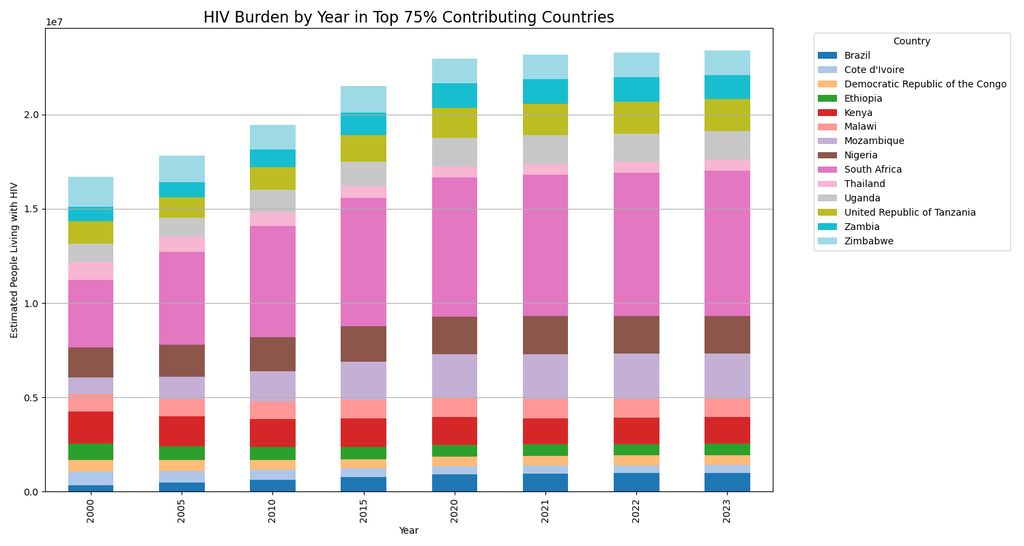

```python
# Total HIV per country
total_by_country = hiv_data.groupby('Country')['HIV_Population'].sum().reset_index()

# Calculate cumulative % contribution
total_by_country = total_by_country.sort_values(by='HIV_Population', ascending=False)
total = total_by_country['HIV_Population'].sum()
total_by_country['CumulativePercent'] = 100 * total_by_country['HIV_Population'].cumsum() / total

# Filter countries that contribute to 75%
top_75_countries = total_by_country[total_by_country['CumulativePercent'] <= 75]['Country']

# Filter and plot
top_data = hiv_data[hiv_data['Country'].isin(top_75_countries)]

# Pivot the data to prepare for bar chart
pivot_df = top_data.pivot_table(index='Year', columns='Country', values='HIV_Population', aggfunc='sum').fillna(0)

# Plot
import matplotlib.pyplot as plt

fig, ax = plt.subplots(figsize=(15, 8))
pivot_df.plot(kind='bar', stacked=True, colormap='tab20', ax=ax)

ax.set_title('HIV Burden by Year in Top 75% Contributing Countries', fontsize=16)
ax.set_ylabel('Estimated People Living with HIV')
ax.set_xlabel('Year')
ax.legend(title='Country', bbox_to_anchor=(1.05, 1), loc='upper left')
ax.grid(axis='y')

plt.tight_layout()
plt.savefig("output.png")  # ✅ Saves image
plt.close()  # ✅ Clean up
```

Generate a visualization that displays the trend of HIV cases in the countries contributing to 75% of the burden within each WHO region (column called ParentLocationCode contains the WHO regions)

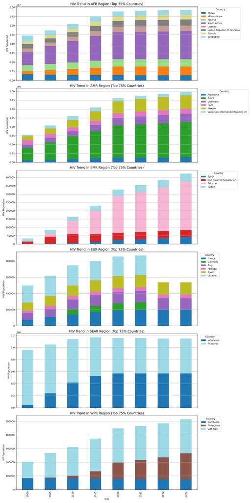

```python
# Calculate total HIV per country within each region
region_country_totals = hiv_data.groupby(['ParentLocationCode', 'Country'])['HIV_Population'].sum().reset_index()

# Identify top 75% contributing countries per region
top_75_countries_by_region = {}

for region in region_country_totals['ParentLocationCode'].unique():
    region_df = region_country_totals[region_country_totals['ParentLocationCode'] == region].sort_values(by='HIV_Population', ascending=False)
    total = region_df['HIV_Population'].sum()
    region_df['CumulativePercent'] = 100 * region_df['HIV_Population'].cumsum() / total
    top_countries = region_df[region_df['CumulativePercent'] <= 75]['Country'].tolist()
    top_75_countries_by_region[region] = top_countries

# Filter original hiv_data for only top 75% countries in each region
filtered_data = hiv_data[
    hiv_data.apply(lambda row: row['Country'] in top_75_countries_by_region.get(row['ParentLocationCode'], []), axis=1)
]

# Plot trends by region
regions = filtered_data['ParentLocationCode'].unique()
n_regions = len(regions)

fig, axes = plt.subplots(n_regions, 1, figsize=(15, 5 * n_regions), sharex=True)

if n_regions == 1:
    axes = [axes]  # make sure it's iterable

for ax, region in zip(axes, regions):
    region_data = filtered_data[filtered_data['ParentLocationCode'] == region]
    pivot_df = region_data.pivot_table(index='Year', columns='Country', values='HIV_Population', aggfunc='sum').fillna(0)

    pivot_df.plot(kind='bar', stacked=True, colormap='tab20', ax=ax)
    ax.set_title(f'HIV Trend in {region} Region (Top 75% Countries)', fontsize=14)
    ax.set_ylabel('HIV Population')
    ax.legend(title='Country', bbox_to_anchor=(1.01, 1), loc='upper left')
    ax.grid(axis='y')

plt.xlabel('Year')
plt.tight_layout()
plt.show()
```

## Combining hiv_data and poverty_data

We would like you to merge this dataset with the HIV data above and analyze the relationship between people living with HIV and multidimensional poverty, and the individual factors that contribute to the ratio. Remember to account for the random effects (country, year).

```python
# Get all possible pairs within same country
df = pd.merge(hiv_data, poverty_data, on='Country', how='inner', suffixes=('_hiv', '_poverty'))

# Calculate year difference
df['YearDiff'] = (df['Year_hiv'] - df['Year_poverty']).abs()

# Keep the row with the smallest year difference per HIV data row
df = df.loc[df.groupby(['Country', 'Year_hiv'])['YearDiff'].idxmin()].copy()

# Rename to keep consistent
df = df.rename(columns={'Year_hiv': 'Year'})
df
```

```
##       Country  Year  ...  Multidimensional_Poverty YearDiff
## 311   Albania  2000  ...                  0.293161       12
## 310   Albania  2005  ...                  0.293161        7
## 309   Albania  2010  ...                  0.293161        2
## 308   Albania  2015  ...                  0.293161        3
## 307   Albania  2020  ...                  0.293161        8
## ..        ...   ...  ...                       ...      ...
## 156  Zimbabwe  2015  ...                 42.397931        2
## 155  Zimbabwe  2020  ...                 42.397931        3
## 154  Zimbabwe  2021  ...                 42.397931        4
## 153  Zimbabwe  2022  ...                 42.397931        5
## 152  Zimbabwe  2023  ...                 42.397931        6
##
## [625 rows x 14 columns]
```

# 6. Modelling

```python
# Log-transform the target variable
df['log_HIV_Population'] = np.log1p(df['HIV_Population'])

# Select predictors
predictors = [
    'Monetary', 'Education_Attainment', 'Education_Enrollment',
    'Electricity', 'Sanitation', 'Drinking_Water', 'Multidimensional_Poverty'
]

# Fixed effects
X = sm.add_constant(df[predictors])

# Mixed effects model — random intercept by country
model = MixedLM(
    endog=df['log_HIV_Population'],
    exog=X,
    groups=df['Country']
)

result = model.fit()

print(result.summary())
```

```
##                Mixed Linear Model Regression Results
## ===================================================================
## Model:             MixedLM  Dependent Variable:  log_HIV_Population
## No. Observations:  625      Method:              REML
## No. Groups:        79       Scale:               0.3270
## Min. group size:   4        Log-Likelihood:      -724.1026
## Max. group size:   8        Converged:           Yes
## Mean group size:   7.9
## -------------------------------------------------------------------
##                          Coef.  Std.Err.   z    P>|z| [0.025 0.975]
## -------------------------------------------------------------------
## const                    10.256    0.383 26.768 0.000  9.505 11.007
## Monetary                 -0.054    0.060 -0.900 0.368 -0.172  0.064
## Education_Attainment     -0.027    0.032 -0.832 0.405 -0.089  0.036
## Education_Enrollment     -0.100    0.036 -2.796 0.005 -0.171 -0.030
## Electricity              -0.070    0.032 -2.153 0.031 -0.134 -0.006
## Sanitation               -0.018    0.018 -1.033 0.301 -0.052  0.016
## Drinking_Water           -0.029    0.040 -0.738 0.461 -0.107  0.048
## Multidimensional_Poverty  0.232    0.095  2.448 0.014  0.046  0.418
## Group Var                 3.040    0.962
## ===================================================================
```

## Interpretation

Multidimensional Poverty is significantly associated with higher HIV population (positive coefficient, p=0.014).

Other factors (Monetary, Sanitation, etc.) may not be statistically significant.

So, multidimensional poverty and education/electricity access are the most influential.